# Polygenic models of gene expression levels in GAIT2. Round 2.

Andrey Ziyatdinov

2015-10-29

# About

## Difference between rounds 1 and 2

In Round 2:

- `c2` house-hold effect is discarded/included by a different rule (see protocol).
- Polygenic models have been computed for all expression traits: some models were manualy re-computed  
  by removing `c2` (most cases) or covariates (a single case).
- Classical polygenic models are estimated with two tools, SOLAR and `lme4`.
- For lme4-based code
  - scaled version of `AGE` covariate is used.
- New analyses were added.
  - Sex-specificity
  - Aging.

# Protocol

## Classical polygenic

1. Read gene expression traits from `Gait2_31082015_genes.raw.scaled.filter.rank` file.
2. Run polygenic model using SOLAR and solarius.
   - `eDateNum` and `eGCMean` covariates are fixed.
   - `AGE` and `SEX` covariates are screened at `0.1` (marginal) significance level.
   - `c2` house-hold effect is screened if it is not significant (alpha `0.1`) or its proportion of variance is below 0.01.

## Sex-specific

The model definition is exactly the same as in (Blangero 2009), but its implementation is based on `lme4` R package.

1. Select expression traits which have `SEX` covariate significant (marginally). There are approximately a half of such traits.
2. Run the polygenic model with sex-specificity.
3. Two p-values are computed per model (see (Blangero 2009) for details), and the minimum between the two values is used for multiple-testing correction.

## Aging

The model is different from the classical polygenic model by a new random effect term “random slope”. It is to be checked if the similar model in (Blangero 2009) has the same form.

## Material

Input data:

- `/home/datasets/GAIT2/Expression/Gait2_31082015/Gait2_31082015_genes.raw.scaled.filter.rank` file on `bioinf02` server at Sant Pau.

Scripts are available on GAIT2 private repository on GitHub.

Output results:

- In a secret folder at DropBox.

## TODO

- Correct the instrumental noise in a different way by a univariate/multivariate method, such a way that it would be not necessary to include `eDateNum` and `eGCMean` covariates in regression models.
- Add a comparison between SOLAR and lme4 models.

Done in Round 2:

- Replace the way SOLAR defines whether to retain `c2` house-hold effect (a random effect with `0.01` of variance is to be removed).
- Estimate the SEX-specific heritability for the gene expression traits.

# Results in brief

A brief version of results is similar to that in (Emilsson et al. 2008):

- table with the number of *heritable* gene expression traits according to a selected FDR threshold (see Emilsson et al. 2008, Table 1);
- histogram of heritability estimate at 0.05 FDR (see Emilsson et al. 2008, Supplementary Figure 2 (c)).

The R code to compute FDR correction is based on function [p.adjust](https://stat.ethz.ch/R-manual/R-devel/library/stats/html/p.adjust.html):

```
p.adjust(pval, method = "fdr") <= alpha
```

## Classical polygenic

| FDR | num | total | perc |
| --- | --- | --- | --- |
| 0.05 | 16,736 | 17,955 | 93.21% |
| 0.01 | 16,000 | 17,955 | 89.11% |
| 0.001 | 14,923 | 17,955 | 83.11% |

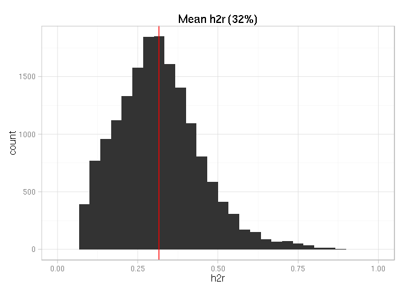

## Sex-specific polygenic

Results of multiple-testing correction.

| FDR | num | total | perc |
| --- | --- | --- | --- |
| 0.05 | 877 | 10,919 | 4.88% |
| 0.01 | 574 | 10,919 | 3.2% |
| 0.001 | 365 | 10,919 | 2.03% |

TOP-10 genes.

|  | TargetID | rho | gsd1 | gsd2 | pval.min | pval.adjust.min |
| --- | --- | --- | --- | --- | --- | --- |
| **5943** | ENSG00000166750.5 | 0.46 | 0.47 | 0.54 | 1.3e-13 | 1.5e-09 |
| **9991** | ENSG00000253797.1 | 0.61 | 0.41 | 0.55 | 7.6e-13 | 3.8e-09 |
| **8703** | ENSG00000215301.5 | 0.77 | 0.38 | 0.5 | 1.2e-12 | 3.8e-09 |
| **2176** | ENSG00000112308.7 | 0.62 | 0.41 | 0.39 | 1.4e-12 | 3.8e-09 |
| **5939** | ENSG00000166734.13 | 0.84 | 0.4 | 0.39 | 1.1e-11 | 1.9e-08 |
| **8892** | ENSG00000225241.3 | 0.62 | 0.62 | 0.6 | 1.2e-11 | 1.9e-08 |
| **7106** | ENSG00000180530.5 | 0.32 | 0.42 | 0.41 | 1.2e-11 | 1.9e-08 |
| **2418** | ENSG00000115935.12 | 0.29 | 0.4 | 0.43 | 1.4e-11 | 1.9e-08 |
| **5211** | ENSG00000159082.13 | 0.71 | 0.39 | 0.41 | 3.1e-11 | 3.8e-08 |
| **7114** | ENSG00000180667.6 | 0.6 | 0.39 | 0.51 | 4.2e-11 | 4.6e-08 |

Comments on Top results:

- Top-1 ENSG00000166750.5 correspond to SLFN5 gene. This gene is Schlafen Family Member 5. May have a role in hematopoietic cell differentiation.
- Top-2 ENSG00000253797.1 correspond to UTP14C gene. UTP14C (UTP14, U3 Small Nucleolar Ribonucleoprotein, Homolog C (Yeast)) is a Protein Coding gene. Among its related pathways are Ribosome biogenesis in eukaryotes. Essential for **spermatogenesis**. May be required specifically for ribosome biogenesis and hence protein synthesis during **male meiosis** (By similarity).

### Enrichment via Reactome

Parameters: pvalueCutoff `0.1`. Number of gene experssion levels (not annotated yet): `877`.

| rank | Description | GeneRatio | BgRatio | p.adjust | geneID | Count |
| --- | --- | --- | --- | --- | --- | --- |
| 1 | Establishment of Sister Chromatid Cohesion | 5/297 | 11/6750 | 0.042 | PDS5B/STAG1/PDS5A/ESCO1/RAD21 | 5 |
| 2 | Mitotic Telophase/Cytokinesis | 5/297 | 14/6750 | 0.042 | PDS5B/NUDC/STAG1/PDS5A/RAD21 | 5 |
| 3 | Mitotic Prometaphase | 13/297 | 100/6750 | 0.042 | NUP133/PDS5B/NUDC/SMC4/NSL1/STAG1/PDS5A/INCENP/RANBP2/CLASP2/RAD21/ERCC6L/CENPP | 13 |
| 4 | Gene Expression | 57/297 | 851/6750 | 0.042 | POLR2B/TPR/TAF2/IARS2/NUP133/PABPC1/CNOT4/GEMIN5/DIS3/RRN3/S…… | 57 |
| 5 | Cohesin Loading onto Chromatin | 4/297 | 10/6750 | 0.042 | PDS5B/STAG1/PDS5A/RAD21 | 4 |
| 6 | Membrane Trafficking | 16/297 | 146/6750 | 0.042 | VTA1/EXOC5/BLOC1S6/CLINT1/SEC24A/EXOC8/RAB14/VPS4B/COPB1/VPS36/APP/AP1G1/ACTB/ACTG1/MYO6/RNF103-CHMP3 | 16 |
| 7 | Resolution of Sister Chromatid Cohesion | 12/297 | 92/6750 | 0.042 | NUP133/PDS5B/NUDC/NSL1/STAG1/PDS5A/INCENP/RANBP2/CLASP2/RAD21/ERCC6L/CENPP | 12 |
| 8 | HIV Transcription Initiation | 8/297 | 45/6750 | 0.042 | POLR2B/TAF2/ERCC2/GTF2F1/TAF5/GTF2E1/GTF2A1/POLR2L | 8 |
| 9 | RNA Polymerase II HIV Promoter Escape | 8/297 | 45/6750 | 0.042 | POLR2B/TAF2/ERCC2/GTF2F1/TAF5/GTF2E1/GTF2A1/POLR2L | 8 |
| 10 | RNA Polymerase II Promoter Escape | 8/297 | 45/6750 | 0.042 | POLR2B/TAF2/ERCC2/GTF2F1/TAF5/GTF2E1/GTF2A1/POLR2L | 8 |
| 11 | RNA Polymerase II Transcription Pre-Initiation And Promoter Opening | 8/297 | 45/6750 | 0.042 | POLR2B/TAF2/ERCC2/GTF2F1/TAF5/GTF2E1/GTF2A1/POLR2L | 8 |
| 12 | RNA Polymerase II Transcription Initiation | 8/297 | 45/6750 | 0.042 | POLR2B/TAF2/ERCC2/GTF2F1/TAF5/GTF2E1/GTF2A1/POLR2L | 8 |
| 13 | RNA Polymerase II Transcription Initiation And Promoter Clearance | 8/297 | 45/6750 | 0.042 | POLR2B/TAF2/ERCC2/GTF2F1/TAF5/GTF2E1/GTF2A1/POLR2L | 8 |
| 14 | HIV Life Cycle | 15/297 | 136/6750 | 0.051 | VTA1/POLR2B/TPR/TAF2/NUP133/ERCC2/VPS4B/GTF2F1/TAF5/RANBP2/GTF2E1/PSIP1/GTF2A1/POLR2L/RNF103-CHMP3 | 15 |
| 15 | Late Phase of HIV Life Cycle | 14/297 | 126/6750 | 0.066 | VTA1/POLR2B/TPR/TAF2/NUP133/ERCC2/VPS4B/GTF2F1/TAF5/RANBP2/GTF2E1/GTF2A1/POLR2L/RNF103-CHMP3 | 14 |
| 16 | HIV Infection | 20/297 | 218/6750 | 0.071 | VTA1/ATP6V1H/POLR2B/TPR/TAF2/NUP133/ERCC2/KPNA1/VPS4B/GTF2F1/TAF5/RANBP2/GTF2E1/PSIP1/GTF2A1/AP1G1/POLR2L/PSMD12/PSMB10/RNF103-CHMP3 | 20 |

### Gene-set enrichment via Reactome

Parameters: minGSSize `10`, pvalueCutoff `0.3`. Number of gene experssion levels (not annotated yet): `10919`.

| rank | Description | setSize | p.adjust |
| --- | --- | --- | --- |
| 1 | Activation of the pre-replicative complex | 20 | 0.23 |
| 2 | Metabolism | 854 | 0.23 |
| 3 | Glycolysis | 19 | 0.23 |
| 4 | DNA strand elongation | 22 | 0.23 |
| 5 | Metabolism of carbohydrates | 140 | 0.23 |
| 6 | Metabolism of proteins | 416 | 0.23 |
| 7 | PD-1 signaling | 15 | 0.23 |
| 8 | Post-translational protein modification | 177 | 0.23 |
| 9 | Transmembrane transport of small molecules | 213 | 0.23 |
| 10 | Gluconeogenesis | 23 | 0.27 |
| 11 | Gene Expression | 603 | 0.27 |
| 12 | Intraflagellar transport | 23 | 0.27 |
| 13 | SLC-mediated transmembrane transport | 100 | 0.27 |

## Aging polygenic

Results of multiple-testing correction.

| FDR | num | total | perc |
| --- | --- | --- | --- |
| 0.05 | 92 | 14,390 | 0.51% |
| 0.01 | 8 | 14,390 | 0.04% |
| 0.001 | 3 | 14,390 | 0.02% |

TOP-10 genes.

|  | TargetID | h2r | h2r.aging | pval.aging | pval.adjust.aging |
| --- | --- | --- | --- | --- | --- |
| **5** | ENSG00000000971.11 | 0.19 | 0.25 | 1.2e-08 | 8.8e-05 |
| **10851** | ENSG00000211671.2 | 0.37 | 0.2 | 1.2e-08 | 8.8e-05 |
| **11596** | ENSG00000227051.4 | 0.5 | 0.24 | 5.2e-08 | 0.00025 |
| **8067** | ENSG00000170476.11 | 0.21 | 0.17 | 5.1e-07 | 0.0018 |
| **12666** | ENSG00000244437.1 | 0.27 | 0.18 | 1.2e-06 | 0.0035 |
| **1297** | ENSG00000091490.6 | 0.33 | 0.18 | 1.7e-06 | 0.0039 |
| **1435** | ENSG00000099958.10 | 0.38 | 0.16 | 1.9e-06 | 0.0039 |
| **847** | ENSG00000074527.7 | 0.15 | 0.22 | 2.5e-06 | 0.0045 |
| **3131** | ENSG00000117143.8 | 0.21 | 0.18 | 6.4e-06 | 0.01 |
| **12418** | ENSG00000239951.1 | 0.26 | 0.16 | 7.3e-06 | 0.01 |

Comments on Top results:

- Top-1 ENSG00000000971.11 correspond to CFH gene, which is a member of the Regulator of Complement Activation (RCA) gene cluster and encodes a protein with twenty short consensus repeat (SCR) domains. Among its related pathways are Pathways in cancer and **Complement and coagulation cascades**. GO annotations related to this gene include **heparin binding** and **heparan sulfate proteoglycan binding**.
- Top-2 has no annotation.
- Top-4 ENSG00000170476.11 is a product of MZB1 gene, which associates with immunoglobulin M (IgM) heavy and light chains and promotes IgM assembly and secretion. Acts as a hormone-regulated adipokine/proinflammatory cytokine that is implicated in causing **chronic inflammation**, affecting cellular expansion and blunting insulin response in adipocytes. May have a role in the onset of insulin resistance.

### Enrichment via Reactome

Parameters: pvalueCutoff `0.1`. Number of gene experssion levels (not annotated yet): `92`.

| rank | Description | GeneRatio | BgRatio | p.adjust | geneID | Count |
| --- | --- | --- | --- | --- | --- | --- |
| 1 | Diseases of Immune System | 3/39 | 24/6750 | 0.043 | BTK/TLR2/TLR5 | 3 |
| 2 | Diseases associated with the TLR signaling cascade | 3/39 | 24/6750 | 0.043 | BTK/TLR2/TLR5 | 3 |

### Gene-set enrichment via Reactome

Parameters: minGSSize `50`, pvalueCutoff `0.15`. Number of gene experssion levels (not annotated yet): `14390`.

| rank | Description | setSize | p.adjust |
| --- | --- | --- | --- |
| 1 | Adaptive Immune System | 302 | 0.013 |
| 2 | Cell Cycle, Mitotic | 327 | 0.013 |
| 3 | Immune System | 648 | 0.013 |
| 4 | Innate Immune System | 390 | 0.013 |
| 5 | Metabolism | 925 | 0.013 |
| 6 | Metabolism of proteins | 466 | 0.055 |
| 7 | Cell Cycle | 382 | 0.059 |
| 8 | Metabolism of carbohydrates | 158 | 0.059 |
| 9 | M Phase | 187 | 0.059 |
| 10 | Translation | 116 | 0.059 |
| 11 | Disease | 432 | 0.06 |
| 12 | HIV Infection | 170 | 0.082 |
| 13 | Class A/1 (Rhodopsin-like receptors) | 102 | 0.086 |
| 14 | Infectious disease | 271 | 0.089 |
| 15 | Gene Expression | 650 | 0.092 |
| 16 | Hemostasis | 273 | 0.11 |
| 17 | RHO GTPase Effectors | 163 | 0.11 |
| 18 | Signaling by the B Cell Receptor (BCR) | 127 | 0.11 |
| 19 | Fc epsilon receptor (FCERI) signaling | 120 | 0.11 |
| 20 | Platelet activation, signaling and aggregation | 117 | 0.12 |
| 21 | GPCR ligand binding | 122 | 0.12 |
| 22 | Cytokine Signaling in Immune system | 182 | 0.13 |
| 23 | HIV Life Cycle | 108 | 0.13 |
| 24 | Programmed Cell Death | 111 | 0.13 |
| 25 | Transmembrane transport of small molecules | 277 | 0.14 |
| 26 | DNA Repair | 121 | 0.14 |
| 27 | SLC-mediated transmembrane transport | 144 | 0.14 |
| 28 | Signaling by Rho GTPases | 241 | 0.14 |
| 29 | Apoptosis | 108 | 0.15 |
| 30 | Interferon Signaling | 114 | 0.15 |

# Results in more detail

*Note*: Results presented below are (1) produced by SOLAR; and (2) extracted for the heritable expression traits only (at `0.05` FDR significance level).

A polygenic model of SOLAR reports other output parameters than `h2r`. One can see below the summary of the model corresponding to the first gene expression trait.

```
Call: solarPolygenic(data = as.data.frame(edat), traits = "expr", covlist = c(covlist.fixed,
    covlist.test), covtest = TRUE, household = household)

File polygenic.out:
    Pedigree:    dat.ped
    Phenotypes:  dat.phe
    Trait:       expr                  Individuals:  916

             H2r is 0.3515963  p = 6.719066e-12  (Significant)
           H2r Std. Error:  0.0624263

              C2 is 0.1065068  p = 0.0093995  (Significant)
            C2 Std. Error:  0.0478243

                                 eDateNum  p = 0.3813424  (Not Sig., but fixed)
                                  eGCMean  p = 1.0734619e-44  (Significant)
                                      AGE  p = 3.3571283e-06  (Significant)
                                      SEX  p = 0.0000445  (Significant)

    35 pedigrees merged into 34 pedigree-household groups

    Proportion of Variance Due to All Final Covariates Is
                  0.2053575

    Loglikelihoods and chi's are in expr/polygenic.logs.out
    Best model is named housepoly and null0
    Final models are named housepoly, house, poly, spor, nocovar
    Initial sporadic and polygenic models are s0 and p0
    Initial household and household polygenic models are h0 and hp0
    Constrained covariate models are named no<covariate name>

    Residual Kurtosis is -0.1362, within normal range
```

R package solarius allows to easily extract the most of the output from SOLAR models.

## Covariates

The models have different sets of covariates, because of screening applied to `AGE` and `SEX`.

| covlist | num | total | perc |
| --- | --- | --- | --- |
| eDateNum, eGCMean, AGE, SEX | 8,396 | 16,736 | 50.17% |
| eDateNum, eGCMean, AGE | 5,156 | 16,736 | 30.81% |
| eDateNum, eGCMean, SEX | 2,018 | 16,736 | 12.06% |
| eDateNum, eGCMean | 1,166 | 16,736 | 6.97% |

## Variance due to covariates

SOLAR computes *Proportion of Variance Due to All Final Covariates* by comparing two models, polygenic and sporadic (without the polygenic effect).

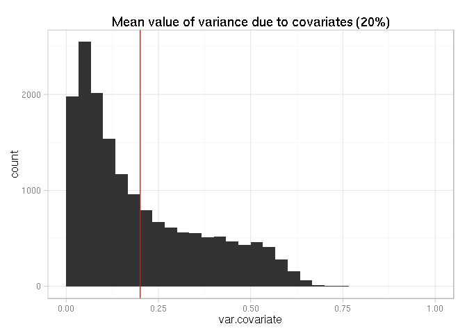

In further analyses, it would be interesting to see the effect of only experimental variables (`eDateNum` and `eGCMean`) in terms of explained variance.

### A model without estimated variance

```
Call: solarPolygenic(data = as.data.frame(edat), traits = "expr", covlist = c(covlist.fixed,
    covlist.test), covtest = TRUE, household = household)

File polygenic.out:
    Pedigree:    dat.ped
    Phenotypes:  dat.phe
    Trait:       expr                  Individuals:  916

             H2r is 0.7611950  p = 5.077276e-38  (Significant)
           H2r Std. Error:  0.0533486

                                 eDateNum  p = 0.8395186  (Not Sig., but fixed)
                                  eGCMean  p = 0.7849673  (Not Sig., but fixed)
                                      SEX  p = 0.0232222  (Significant)

    Proportion of Variance Due to All Final Covariates Is
        [Not Estimable due to Instability]
        [Some covariate effects may be relatively small]
        [Consider running fewer covariates or 'bayesavg -cov']

    Loglikelihoods and chi's are in expr/polygenic.logs.out
    Best model is named poly and null0
    Final models are named poly, spor, nocovar
    Initial sporadic and polygenic models are s0 and p0
    Constrained covariate models are named no<covariate name>

    Residual Kurtosis is -0.1010, within normal range
```

## Household effect

| model | num | total | perc |
| --- | --- | --- | --- |
| c2.zero | 12,170 | 16,736 | 72.72% |
| c2.nonzero | 4,566 | 16,736 | 27.28% |

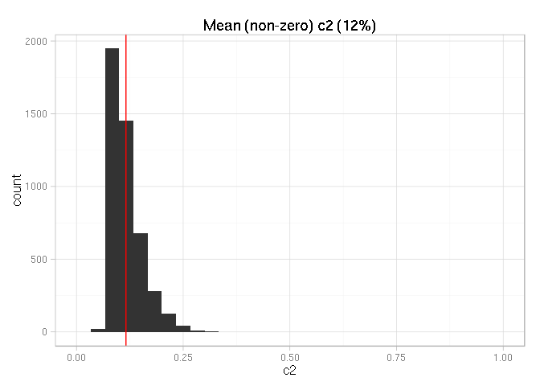

## Residual kurtosis

Although the gene expression traits were transformed according to rank-based transformation (informal), one can plot the actual values of residual kurtosis of the models. Note that the critical value of residual kurtosis posed by SOLAR is `0.8`.

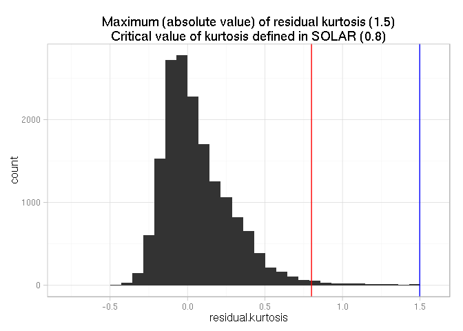

References

Blangero, John. 2009. “Statistical Genetic Approaches to Human Adaptability.” *Human Biology* 81 (5). Wayne State University Press: 523–46.

Emilsson, Valur, Gudmar Thorleifsson, Bin Zhang, Amy S Leonardson, Florian Zink, Jun Zhu, Sonia Carlson, et al. 2008. “Genetics of Gene Expression and Its Effect on Disease.” *Nature* 452 (7186). Nature Publishing Group: 423–28.